# HIV Infection Analysis Dimension Reduction of DMSO, SAHA and PMA Datasets

## 2.3 Log-normalisation (CPM + log2)

To reduce library-size bias we compute **log2(CPM + 1)**.

```r
library_sizes <- rowSums(counts_t)


counts_cpm <- sweep(counts_t, MARGIN = 1, STATS = library_sizes, FUN = "/") * 1000000

counts_log <- log2(counts_cpm + 1)

cat("Library sizes – summary:\n"); print(summary(library_sizes))
```

```
## Library sizes – summary:
```

```
##    Min. 1st Qu.  Median    Mean 3rd Qu.    Max.
##   29184  133784  374878  344827  464402 1026101
```

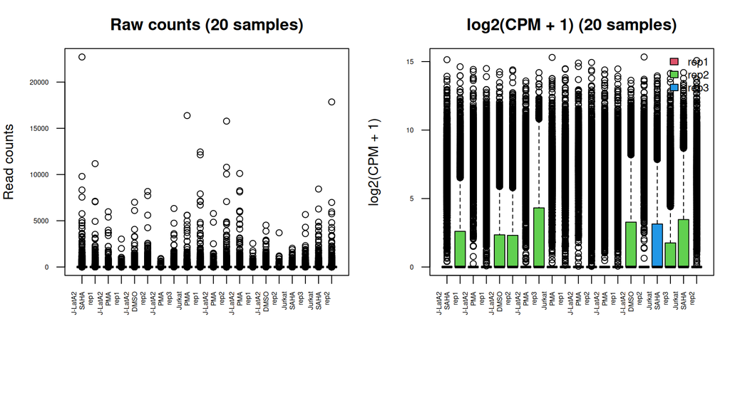

```r
set.seed(42)
idx <- sample(nrow(counts_t), 20)
labels_sub <- paste(metadata$cell_type[idx], metadata$treatment[idx],
                    metadata$replicate[idx], sep = "\n")

par(mfrow = c(1, 2), mar = c(8, 4, 3, 1))

boxplot(t(counts_t[idx, ]),
        las = 2, cex.axis = 0.5,
        col  = as.integer(factor(metadata$replicate[idx])) + 1,
        main = "Raw counts (20 samples)",
        ylab = "Read counts", names = labels_sub)

boxplot(t(counts_log[idx, ]),
        las = 2, cex.axis = 0.5,
        col  = as.integer(factor(metadata$replicate[idx])) + 1,
        main = "log2(CPM + 1) (20 samples)",
        ylab = "log2(CPM + 1)", names = labels_sub)
legend("topright", legend = c("rep1","rep2","rep3"),
       fill = 2:4, bty = "n", cex = 0.8)
```

```r
par(mfrow = c(1, 1))
```

## 2.4 Scaled PCA (z-score across genes)

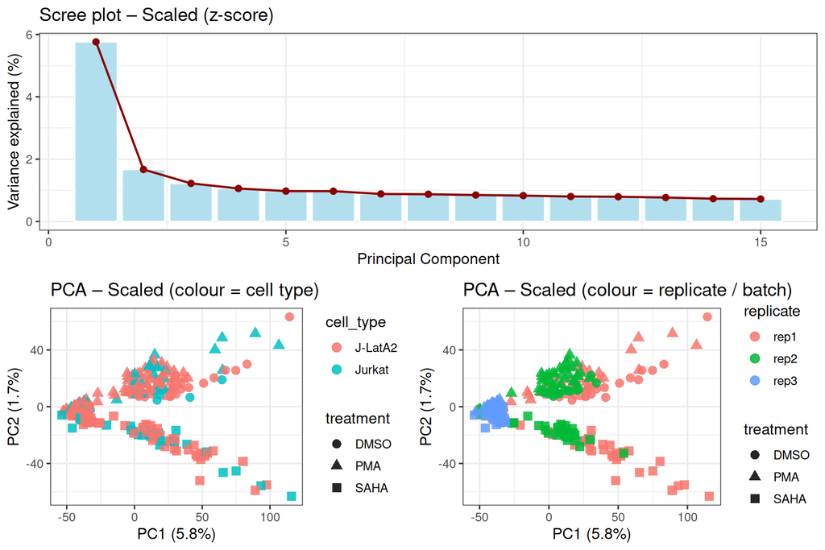

```r
pca_scaled <- run_pca(counts_t, scale. = TRUE, center = TRUE)

var_scaled  <- pca_var_explained(pca_scaled)
sc_scaled   <- pca_scores_df(pca_scaled, metadata)

xlab_sc <- paste0("PC1 (", round(var_scaled$variance[1], 1), "%)")
ylab_sc <- paste0("PC2 (", round(var_scaled$variance[2], 1), "%)")

p4 <- plot_scree(var_scaled, title = "Scree plot – Scaled (z-score)")

p5 <- plot_pca(sc_scaled, colour_var = "cell_type", shape_var = "treatment",
               title = "PCA – Scaled (colour = cell type)",
               xlab = xlab_sc, ylab = ylab_sc)

p6 <- plot_pca(sc_scaled, colour_var = "replicate", shape_var = "treatment",
               title = "PCA – Scaled (colour = replicate / batch)",
               xlab = xlab_sc, ylab = ylab_sc)

grid.arrange(p4, p5, p6, layout_matrix = rbind(c(1,1), c(2,3)))
```

## 2.5 PCA on log2(CPM + 1) normalised data

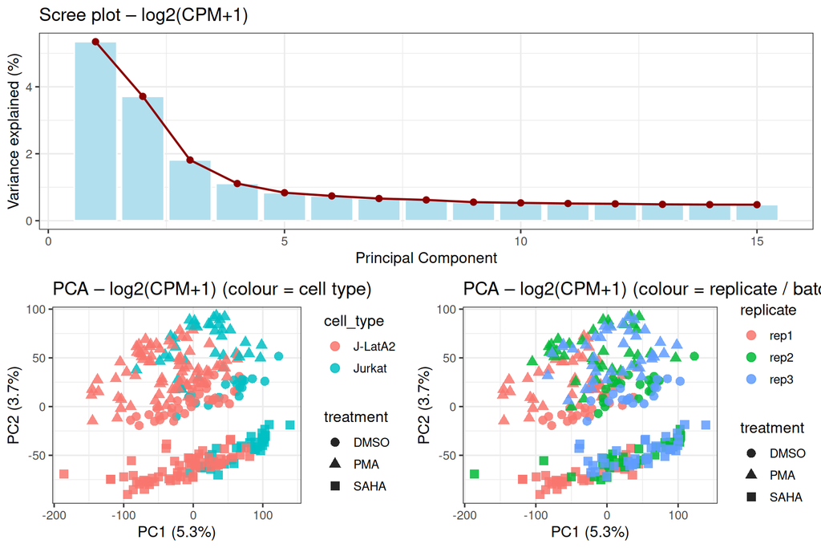

```r
pca_norm <- run_pca(counts_log, scale. = FALSE, center = TRUE)

var_norm  <- pca_var_explained(pca_norm)
sc_norm   <- pca_scores_df(pca_norm, metadata)

xlab_norm <- paste0("PC1 (", round(var_norm$variance[1], 1), "%)")
ylab_norm <- paste0("PC2 (", round(var_norm$variance[2], 1), "%)")

p7 <- plot_scree(var_norm, title = "Scree plot – log2(CPM+1)")

p8 <- plot_pca(sc_norm, colour_var = "cell_type", shape_var = "treatment",
               title = "PCA – log2(CPM+1) (colour = cell type)",
               xlab = xlab_norm, ylab = ylab_norm)

p9 <- plot_pca(sc_norm, colour_var = "replicate", shape_var = "treatment",
               title = "PCA – log2(CPM+1) (colour = replicate / batch)",
               xlab = xlab_norm, ylab = ylab_norm)

grid.arrange(p7, p8, p9, layout_matrix = rbind(c(1,1), c(2,3)))
```

## 2.6 Variance explained – comparison table

```r
var_compare <- data.frame(
  PC          = 1:10,
  Raw         = round(var_raw$variance[1:10], 2),
  Scaled      = round(var_scaled$variance[1:10], 2),
  log2_CPM    = round(var_norm$variance[1:10], 2)
)
kable(var_compare,
      caption = "% variance explained by PC1–10 under different preprocessing")
```

% variance explained by PC1–10 under different preprocessing

| PC | Raw | Scaled | log2_CPM |
| --- | --- | --- | --- |
| 1 | 48.76 | 5.76 | 5.35 |
| 2 | 19.41 | 1.67 | 3.71 |
| 3 | 6.78 | 1.22 | 1.81 |
| 4 | 4.18 | 1.06 | 1.11 |
| 5 | 2.71 | 0.97 | 0.84 |
| 6 | 1.79 | 0.97 | 0.74 |
| 7 | 1.59 | 0.88 | 0.66 |
| 8 | 1.22 | 0.87 | 0.62 |
| 9 | 1.05 | 0.85 | 0.55 |
| 10 | 0.77 | 0.83 | 0.53 |

## 2.7 Batch effect assessment

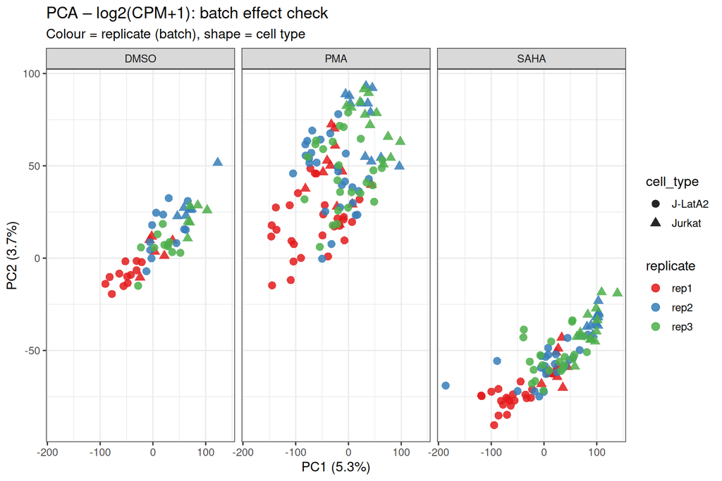

```r
ggplot(sc_norm, aes(x = PC1, y = PC2,
                    colour = replicate, shape = cell_type)) +
  geom_point(size = 3, alpha = 0.85) +
  facet_wrap(~treatment) +
  labs(title = "PCA – log2(CPM+1): batch effect check",
       subtitle = "Colour = replicate (batch), shape = cell type",
       x = xlab_norm, y = ylab_norm) +
  scale_colour_brewer(palette = "Set1") +
  theme_bw(base_size = 12)
```

**Interpretation – Batch effects:**  
Visualizing the log-normalized data by replicate confirms a mild batch effect: samples from replicate 1 tend to cluster separately from replicates 2 and 3. However, the biological signal (cell type and treatment) remains the dominant driver of variance. Based on the initial dataset quality control guidelines, no outliers require removal.

## 2.8 PC1/PC2 correlation with metadata variables

Here we did this Kruskal-Wallis test, because as we only have n=3 replicates, we can’t assume normality, making a non-parametric test like Kruskal-Wallis much safer than an ANOVA. Also the design is unbalanced, and Kruskal-Wallis handles unequal group sizes and variances better, avoiding potential false positives. It works for both 2 groups (cell type) and 3 groups (treatment), so we could use the same statistical test for every variable. This allowed us to wrap everything in a for loop, making the code much cleaner, more efficient, and easier to automate.

```r
covariables <- c("cell_type", "treatment", "replicate")

pc_pvals <- data.frame(
  PC1_p = sapply(covariables, function(x) kruskal.test(sc_norm$PC1 ~ as.factor(sc_norm[[x]]))$p.value),
  PC2_p = sapply(covariables, function(x) kruskal.test(sc_norm$PC2 ~ as.factor(sc_norm[[x]]))$p.value)
)

print(round(pc_pvals, 4))
```

```
##           PC1_p  PC2_p
## cell_type     0 0.0019
## treatment     0 0.0000
## replicate     0 0.0003
```

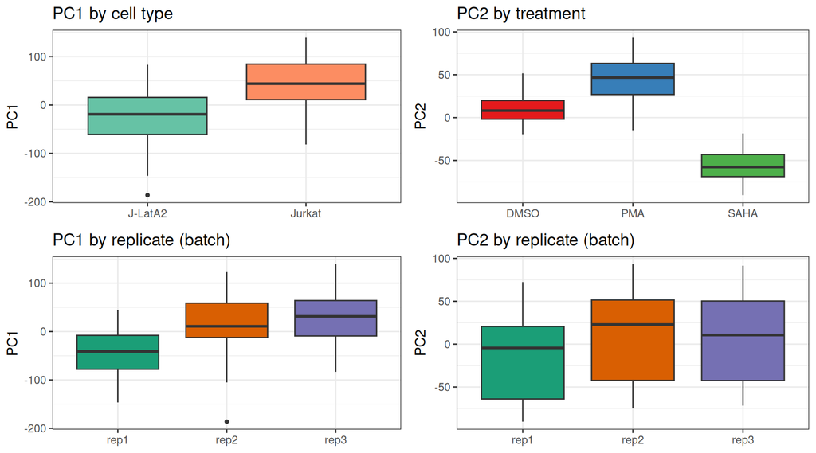

```r
b1 <- ggplot(sc_norm, aes(x = cell_type, y = PC1, fill = cell_type)) +
  geom_boxplot(outlier.size = 1) +
  scale_fill_brewer(palette = "Set2") +
  labs(title = "PC1 by cell type", x = NULL) +
  theme_bw(base_size = 11) + theme(legend.position = "none")

b2 <- ggplot(sc_norm, aes(x = treatment, y = PC2, fill = treatment)) +
  geom_boxplot(outlier.size = 1) +
  scale_fill_brewer(palette = "Set1") +
  labs(title = "PC2 by treatment", x = NULL) +
  theme_bw(base_size = 11) + theme(legend.position = "none")

b3 <- ggplot(sc_norm, aes(x = replicate, y = PC1, fill = replicate)) +
  geom_boxplot(outlier.size = 1) +
  scale_fill_brewer(palette = "Dark2") +
  labs(title = "PC1 by replicate (batch)", x = NULL) +
  theme_bw(base_size = 11) + theme(legend.position = "none")

b4 <- ggplot(sc_norm, aes(x = replicate, y = PC2, fill = replicate)) +
  geom_boxplot(outlier.size = 1) +
  scale_fill_brewer(palette = "Dark2") +
  labs(title = "PC2 by replicate (batch)", x = NULL) +
  theme_bw(base_size = 11) + theme(legend.position = "none")

grid.arrange(b1, b2, b3, b4, nrow = 2)
```

**Interpretation – PC correlation:**  
Statistical testing (Kruskal-Wallis) confirms:  
- PC1 is strongly associated with cell type (Jurkat vs. J-LatA2).  
- PC2 is associated with treatment (DMSO vs. SAHA vs. PMA).  
- Replicate / batch shows moderate influence on both PCs, confirming a batch effect that warrants downstream correction before differential expression.

# Question 3 – t-SNE Representation

## 3.1 Helper function for t-SNE

```r
run_tsne <- function(mat, perplexity = 30, max_iter = 1000,
                     check_duplicates = FALSE, pca = TRUE, seed = 42) {
  set.seed(seed)
  Rtsne(as.matrix(mat),
        perplexity       = perplexity,
        max_iter         = max_iter,
        check_duplicates = check_duplicates,
        pca              = pca,
        verbose          = FALSE)
}

plot_tsne <- function(tsne_obj, metadata, colour_var, shape_var = NULL,
                      title = "t-SNE", palette = NULL) {
  df <- data.frame(
    tSNE1 = tsne_obj$Y[, 1],
    tSNE2 = tsne_obj$Y[, 2],
    metadata
  )
  p <- ggplot(df, aes_string(x = "tSNE1", y = "tSNE2",
                              colour = colour_var,
                              shape  = shape_var)) +
    geom_point(size = 3, alpha = 0.85) +
    labs(title = title, x = "t-SNE 1", y = "t-SNE 2") +
    theme_bw(base_size = 12)
  if (!is.null(palette)) p <- p + scale_colour_manual(values = palette)
  p
}
```

## 3.2 t-SNE on raw counts

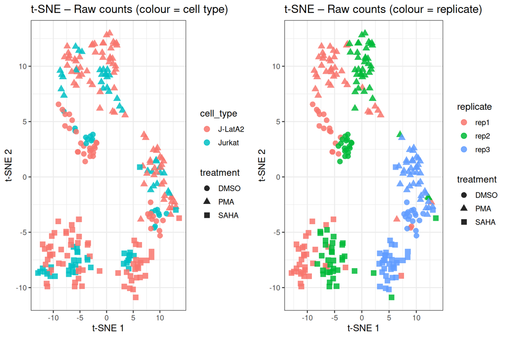

```r
tsne_raw <- run_tsne(counts_t, perplexity = 30)

p_tsne_raw_ct <- plot_tsne(tsne_raw, metadata,
  colour_var = "cell_type", shape_var = "treatment",
  title = "t-SNE – Raw counts (colour = cell type)")

p_tsne_raw_rep <- plot_tsne(tsne_raw, metadata,
  colour_var = "replicate", shape_var = "treatment",
  title = "t-SNE – Raw counts (colour = replicate)")

grid.arrange(p_tsne_raw_ct, p_tsne_raw_rep, ncol = 2)
```